# EEMB 179/279: Lab 4 Disease Models

your name here

30 January 2025

# Important Deadlines

**Friday 31 January 2025** – IN LECTURE: The last half of lecture will function as a review session for Midterm 1, so please bring questions for Dr. Moeller if you have them. A study guide has been posted.

Midterm 1 Study Guide: https://docs.google.com/spreadsheets/d/1Wys5W7DC5B5NhU-okOugY9HCMmjSlKsjScbR2JMXkis/edit?usp=sharing

Recommended Problems Crowd-sourced Key: https://docs.google.com/document/d/1B092j7aWH-TtgIOvnvI-MrpH_b0u-Y26CJAmKfyxpmU/edit?usp=sharing

**Sunday, Feb 2 2025, from 4-6pm via Zoom** – Review Session 1 (see Class Announcement for zoom link)

**Tuesday 4 February 2025** – Paper selection (first choice and alternate) on this google sheet (https://docs.google.com/spreadsheets/d/1vcWsQ1MsTFamkS7lli94J-wor0p8dbMePD17rWS304s/edit?usp=sharing) – make sure to navigate to your section’s tab!

**Wednesday 5 February 2025** – Midterm 1

**Thursday 6 February 2025** – IN LAB: Appointments with Dr. Moeller and Raine in lab about your paper choices. We expect you to – (1) have read both papers, and (2) explain to us why you have chosen this paper (For example – What interests you about it? What ecological concept(s) does this paper address? Which portion will you analytically develop during your presentation? What time series simulation will you code up (and vary a parameter for) in your written report?). Refer to the Project guidelines on Canvas for more details!

**Monday 10 February 2025 by 11:55 pm** – Homework 4 (Modeling Spread of Infectious Disease Lab) Due. **Note the change from usual due date. You have an extra five days to complete Homework 4.**

# EEMB 179: Lab 4 - Modeling the spread of infectious disease

In this lab, we will simulate the spread of an infectious disease, and study how (1) infectiousness, (2) duration of illness, and (3) vaccination impact the potential ‘epidemic’ nature of the disease.

This lab has 2 parts (plus homework):

First, we will work in small groups (of 3 or 4) to perform a virtual simulation of disease spread.

We’ll enter the data from our virtual simulations into a Google Sheet. We can compare how different parameters altered our simulations.

Second, we’ll simulate disease spread using computer models coded in R. This is a much less labor-intensive way of simulating disease spread! That means we’ll be able to study the effects of a wide range of parameters (e.g., beta, gamma, and p) in a short amount of time.

# Lab

## 0. Download deSolve

If you don’t already have the package `deSolve`, uncomment this line of code and run it!

```r
#install.packages("deSolve", dependencies = T)
```

To load in the package, run either of these two lines (they do the same thing).

```r
library(deSolve)
require(deSolve) # remember you can use either library() or require()
```

And last, at the end of this script, you’ll find the homework assignment for this week.

##1. Virtual simulation - Have fun!

We will be using a virtual disease simulation tool to explore epidemic scenarios. Each group will be altering at least 2 parameters in a series of models. Think about what results your manipulations might lead to. Does the model reflect your hypothesis? http://tachyondecay.github.io/epidemic-simulator/

In your groups, fill out the spreadsheet describing the results of your simulations. Your TA will assign your group number. https://docs.google.com/spreadsheets/d/19T6cgB47P22uoRGAsf0ANsl6i1hXjj0Gl0Yaz574IJQ/edit?usp=sharing

##2. Simulating disease computationally

Throughout this section, we’ll be using the following equations:

$$\begin{align}
\frac{d N}{dt} &= 0 \\
\newline
\frac{d S}{dt} &= -\beta S I\\
\newline
\frac{d I}{dt} &= \beta S I - \gamma I\\
\newline
\frac{d R}{dt} &= \gamma I\\
\end{align}$$

###a. Basic disease simulation using a `for()` loop or an ODE Solver

In this class, we use `for()` loops to analyze our models. However, there are tools called **ODE solvers** that are packages that will also analyze your model. “ODE” stands for **O**rdinary **D**ifferential **E**quations, which is what our models are made of (see above). We’re showing you this tool in order to present another option for you to use, in particular in your final project.

ODE solvers are especially useful when you’re solving equations that are “computationally intensive” - generally, these are complex networks of equations. None of the equations we work on in this class are necessarily computationally intensive, so they’re great practice to get the hang of using an ODE solver.

####Simulation using a `for()` loop

First, let’s set up our parameters $\beta$ (infection rate) and $\gamma$ (recovery rate). Remember that you can see LaTeX text (everything between the $ operators) rendered if you hover your cursor above it.

```r
beta <- 0.01   # infection rate
gamma <- 0.1  # recovery rate
```

Second, let’s specify the initial conditions for our simulation. Here, we’re assuming this is a new disease that is introduced to the population by 1 person. Therefore, $S_0 = N - I_0$ because all individuals are susceptible to the disease. Additionally, because the disease is new, there are no recovered individuals ($R_0 = 0$)

```r
# total population
N <- 100

# initial conditions for infected. 1 person is infected
I0 <- 1

# everyone except our infected person
S0 <- N - I0

# no one is recoevered because no one has seen it before
R0 <- 0
```

Third, we’ll set up our storage variables and fill them with our initial conditions. **Note:** Now we’ll need one for each “state” of the population.

```r
# time series
tset <- seq(from = 0, to = 60, length.out = 20000)

# set up empty box for population
N.simu1 <- NaN*tset
N.simu1[1] <- N

# set up empty box for infected
I.simu1 <- NaN*tset
I.simu1[1] <- I0

# set up empty box for S
S.simu1 <- NaN*tset
S.simu1[1] <- S0

# set up empty box for R
R.simu1 <- NaN*tset
R.simu1[1] <- 0
```

Fourth, we’ll run a `for()` loop to simulate the dynamics of the system. This is has the same format as what we’ve been using in previous labs to calculate population sizes at each time step, but with a small modification: within the loop, we create variables called `S`, `I`, and `R` for the population sizes at the previous timestep (e.g. `S.simu1[i-1]`).

These variables get overwritten with each iteration of the `for()` loop, so they’re somewhat inefficient. However, they make the equations for `dS`, `dI`, and `dR` more simple and therefore less prone to error, so it’s worth doing.

```r
# set up for loop i in 2 because we have initial conditions
for(i in 2:length(tset)){
  # delta t (length of time steps)
    dt <- tset[i]-tset[i-1]

    # assigning to single object
    S <- S.simu1[i-1]
    I <- I.simu1[i-1]
    R <- R.simu1[i-1]

    # equations!!!
    dS <- (-beta*S*I)*dt
    dI <- (beta*S*I-gamma*I)*dt
    dR <- (gamma*I)*dt
    dN <- dS+dI+dR

    # classic last step- add our change to the previous value
    S.simu1[i] <- S + dS
    I.simu1[i] <- I + dI
    R.simu1[i] <- R + dR
    N.simu1[i] <- N + dN
}
```

Make sure you check the output of your `for()` loop! Use `head()` and `tail()` to look at the beginning and end to make sure things ran the way they were supposed to.

We’ll check `S.simu1`.

```r
head(S.simu1)
```

```
## [1] 99.00000 98.99703 98.99405 98.99107 98.98807 98.98507
```

```r
tail(S.simu1)
```

```
## [1] 0.004664548 0.004664488 0.004664429 0.004664369 0.004664309 0.004664250
```

Looks like the loop worked! Now, we can create a few plots to examine our output. We’ll be making a lot of timeseries plots where lines are laid on top of each other, so we can store some colors to use that are consistent across each plot.

```r
Ncol <- 'black'
Scol <- 'dodgerblue3'
Icol <- 'coral'
Rcol <- 'darkgoldenrod4'
```

First, let’s double check that we coded everything in correctly by checking the output of `N.simu1`. Remember that $\frac{dN}{dt} = 0$, so $N$ should be the same at each timestep. We’ll plot $N$ as a function of time first, and what we expect is a horizontal line with a y-intercept at 100.

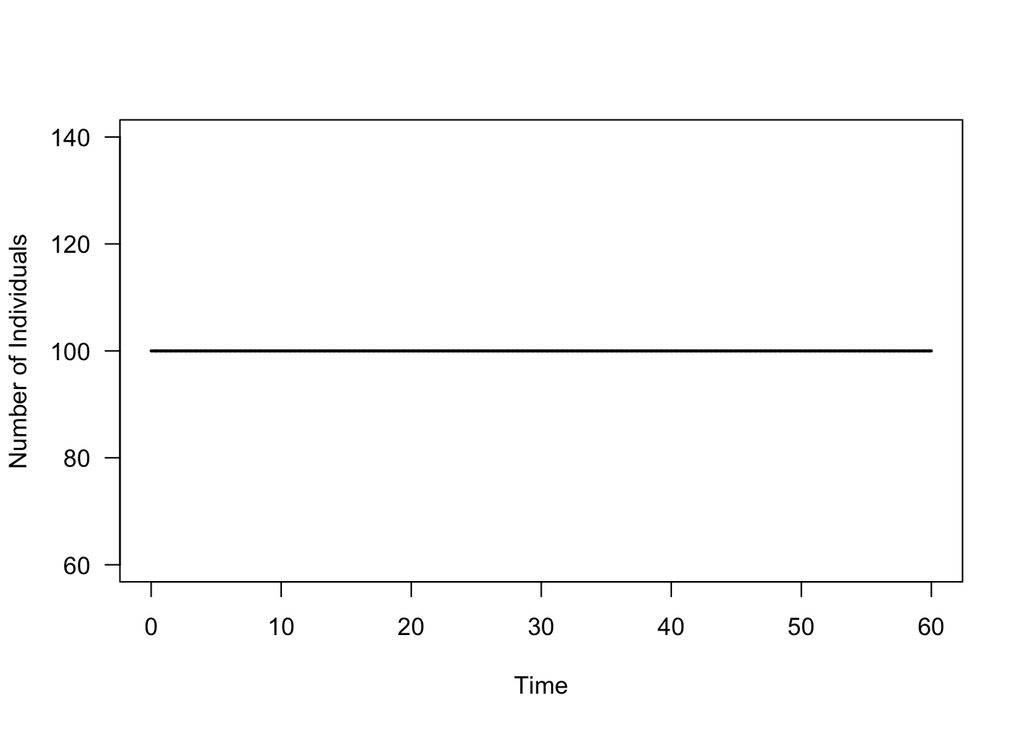

```r
plot(x = tset, y = N.simu1,
     type = 'l',
     col = Ncol,
     las = 1,
     lwd = 2,
     xlab = 'Time', ylab = 'Number of Individuals')
```

Looks like it worked! We can also check by looking at the standard deviation of `N.simu1` using the `sd()` function *or* looking at the last number in `N.simu1`.

```r
sd(N.simu1) #should be zero
```

```
## [1] 0
```

```r
N.simu1[length(tset)] #should be 100 bc no change
```

```
## [1] 100
```

Now, let’s look at how individuals moved between classes using a timeseries plot.

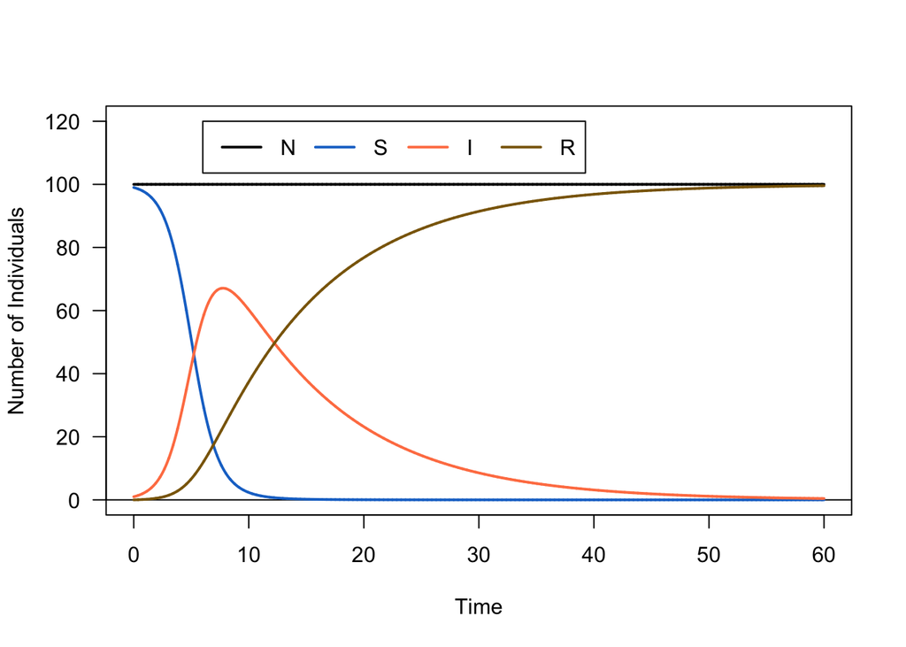

```r
# base plot with population size
plot(x = tset, y = N.simu1,
     type = 'l',
     col = Ncol,
     las = 1,
     lwd=2,
     xlab = 'Time', ylab = 'Number of Individuals',
     ylim = c(0,N*1.2))

# make a line that crosses at 0
abline(h = 0)

# line for S over time
lines(x = tset, y = S.simu1, col = Scol, lwd = 2)
# line for I over time
lines(x = tset, y = I.simu1, col = Icol, lwd = 2)
# line for R over time
lines(x = tset, y = R.simu1, col = Rcol, lwd = 2)

# build legend
legend(x = max(tset)*0.1, y = N*1.2,
       lwd = 2,
       legend = c('N', 'S', 'I', 'R'),
       col = c(Ncol, Scol, Icol, Rcol),
       horiz = TRUE)
```

####Simulation using an ODE solver `deSolve`

The first thing you have to do is set up a function using the `function()` function. This describes your system of equations for the ODE solver to solve.

`deSolve` expects a function with a specific structure: one that takes arguments `t`, `x`, and `params`. These represent time, population size, and parameters, respectively. The folowing code chunk creates a function called `sir.fun` with these arguments. At the end of the function, the `return()` component lets the function output `dSdt`, `dIdt`, `dRdt`, and `dNdt` at each time step.

```r
sir.fun <- function (t, x, params) {
  # population sizes
  S <- x[1]
  I <- x[2]
  R <- x[3]
  N <- x[4]

  # parameters
  beta <- params[1]
  gamma <- params[2]

  # change in population size over change in time
  dSdt <- -beta*S*I #no *dt
  dIdt <- (beta*S*I)-(gamma*I)
  dRdt <- gamma*I
  dNdt <- dSdt+dIdt+dRdt

  # function outputs
  return(list(c(dSdt, dIdt, dRdt, dNdt)))
}
```

Take a moment to look at the equations in the function. What’s different about these in comparison to the equations in the `for()` loop?

Now, we can set up our initial conditions to go into the arguments `t`, `x`, and `params`, which will then go into the ODE solver’s solving function called `lsoda()`. We’re using the same initial conditions as we were for the `for()` loop, but let’s just assign those values again. We’ll also put all these into a **named vector**, which is a vector of numbers where each number has a name. In this example, `S0` is called `S`, `I0` is called `I`, etc.

```r
# total population size
N0 <- 100

# initial number infected
I0 <- 1

# initial number susceptible
S0 <- N - I0

# initial number recovered
R0 <- 0

# named vector of initial values
initial_values <- c(S = S0, I = I0, R = R0, N = N)
```

We can do the same thing for our parameters `beta` and `gamma`, and put them into a vector called `parameters`.

```r
# infectivity rate
beta <- 0.01

# recovery rate
gamma <- 0.1

# vector of parameters
parameters <- c(beta, gamma)
```

The last thing we’ll do is create our time vector, called `times`.

```r
times <- seq(from = 0, to = 60, length.out = 20000)
```

Now we’re ready to run `lsoda()`! If you’re curious about the arguments it takes, check out the help page (`?lsoda`). We’ll store the output as the variable `results`.

```r
results <- lsoda(initial_values, times, sir.fun, parameters)
```

We can also double check the output by using `head()`, as before.

```r
head(results)
```

```
##            time        S        I            R   N
## [1,] 0.00000000 99.00000 1.000000 0.0000000000 100
## [2,] 0.00300015 98.99703 1.002674 0.0003004161 100
## [3,] 0.00600030 98.99404 1.005354 0.0006016353 100
## [4,] 0.00900045 98.99105 1.008042 0.0009036599 100
## [5,] 0.01200060 98.98806 1.010737 0.0012064917 100
## [6,] 0.01500075 98.98505 1.013439 0.0015101331 100
```

We wanted to compare the ODE solver to a `for()` loop, so let’s plot the outputs to do that. First, we’ll plot the outputs from the ODE solver:

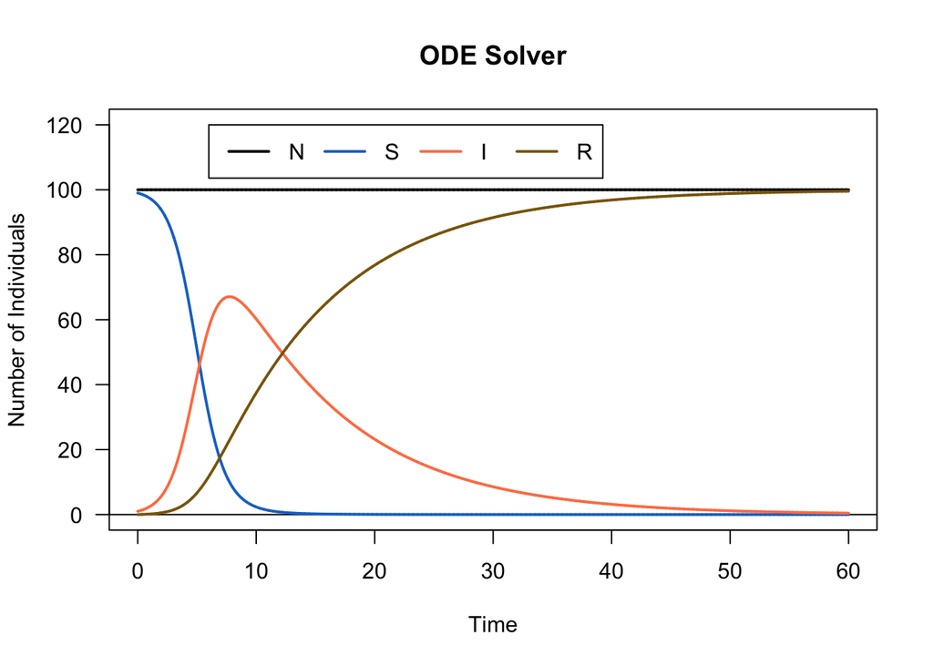

```r
# plot N from ODE solver
plot(x = results[, "time"], y = results[, "N"],
     # line modifications
     type = 'l', col = Ncol, las = 1, lwd = 2,
     # y-axis limits
     ylim = c(0, N*1.2),
     # labels
     xlab = 'Time', ylab = 'Number of Individuals',
     main = "ODE Solver")

# add a horizontal line at 0
abline(h = 0)

# plot S, I, and R from ODE solver
lines(x = results[, "time"], y = results[, "S"], col = Scol, lwd = 2)
lines(x = results[, "time"], y = results[, "I"], col = Icol, lwd = 2)
lines(x = results[, "time"], y = results[, "R"], col = Rcol, lwd = 2)

# add a legend
legend(x = max(tset)*0.1, y = N*1.2,
       lwd= 2,
       legend = c('N', 'S', 'I', 'R'),
       col = c(Ncol, Scol, Icol, Rcol),
       horiz = TRUE)
```

Then, we’ll plot the output from the `for()` loop:

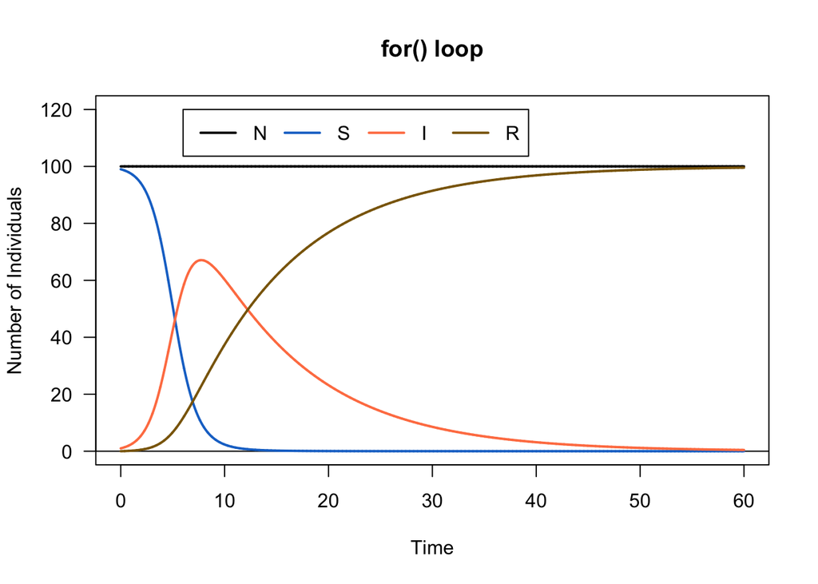

```r
# plot N.simu1 from for() loop
plot(x = tset, y = N.simu1,
     # line modifications
     type = 'l', col=Ncol, las = 1, lwd=2,
     # y-axis limits
     ylim = c(0, N*1.2),
     # labels
     xlab = 'Time', ylab = 'Number of Individuals', main = "for() loop")

# add a horizontal line at 0
abline(h = 0)

# plot S.simu1, I.simu1, and R.simu1 from for() loop
lines(x = tset, y = S.simu1, col = Scol, lwd = 2)
lines(x = tset, y = I.simu1, col = Icol, lwd = 2)
lines(x = tset, y = R.simu1, col = Rcol, lwd = 2)

# add a legend
legend(x = max(tset)*0.1, y = N*1.2,
       lwd = 2,
       legend = c('N', 'S', 'I', 'R'),
       col = c(Ncol, Scol, Icol, Rcol),
       horiz = TRUE)
```

Looks like they’re the same! Now, let’s compare **incidence plots**, where number of infected individuals is plotted as a function of time:

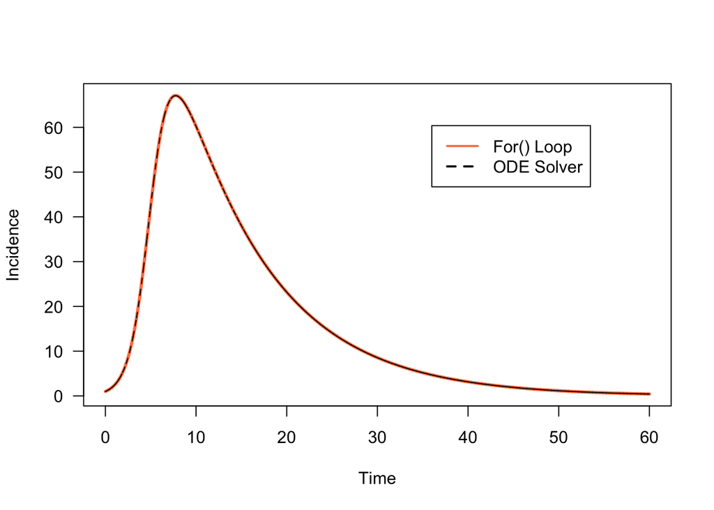

```r
# plot I.simu1 from for() loop
plot(x = tset, y = I.simu1,
     type = 'l', las = 1, col = Icol, lwd = 3,
     xlab = 'Time', ylab = 'Incidence')

# plot I from ODE solver
lines(x = results[, "time"], y = results[, "I"],
      col = 'black', lwd = 1, lty = 2)

# add a legend
legend(x = max(tset)*0.6, y = max(I.simu1)*0.9,
       lwd = 2,
       legend = c('For() Loop', 'ODE Solver'),
       col = c(Icol, 'black'),
       lty = c(1, 2))
```

Again, they look the same. Hooray! Now, for the final test: comparing run times. Which is faster, the `for()` loop or the ODE solver? We can figure this out using the `system.time()` function.

```r
# for() loop run time
for.loop.time <- system.time(
  for(i in 2:length(tset)){
    dt <- tset[i]-tset[i-1]
    S <- S.simu1[i-1]
    I <- I.simu1[i-1]
    R <- R.simu1[i-1]
    dS <- (-beta*S*I)*dt
    dI <- (beta*S*I-gamma*I)*dt
    dR <- (gamma*I)*dt
    dN <- dS+dI+dR
    S.simu1[i] <- S + dS
    I.simu1[i] <- I + dI
    R.simu1[i] <- R + dR
    N.simu1[i] <- N + dN
  }
)

# ODE run time
ode.time <- system.time(
  lsoda(initial_values, times, sir.fun, parameters)
)

# Compare
for.loop.time
```

```
##    user  system elapsed
##   0.022   0.000   0.022
```

```r
ode.time
```

```
##    user  system elapsed
##   0.164   0.005   0.171
```

####Think, Pair, Share 1 : 1. What was the maximum number of people that were sick (i.e., in state $I$) at any given time? What R command can you use to find out exactly?

```r
max(I.simu1)
```

```
## [1] 67.09176
```

2. By the time the disease had run its course (i.e., $I$ had fallen back close to zero), what proportion of the population had been sick at some point? Make a plot of the proportion of individuals that were currently, or had been, sick (i.e., $\frac{I + R}{N}$ over time).

```r
(I+R)/N
```

```
## [1] 0.9999534
```

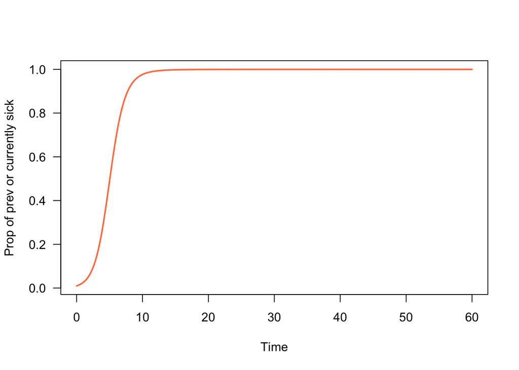

```r
plot(x=tset, y= (I.simu1+R.simu1)/N.simu1,
     type= 'l', las=1, col=Icol, lwd=2,
     xlab='Time', ylab='Prop of prev or currently sick')
```

```r
#pull the value
(N- S.simu1[length(tset)])/N
```

```
## [1] 0.9999534
```

3. When was the rate of transmission highest? You can figure this out by making a plot of the new infections over time. Hint: remember that the change in number of infected individuals over change in time is $\frac{d I}{dt} = \beta S I - \gamma I$, but that the *new infections* would be $\beta * S * I$.

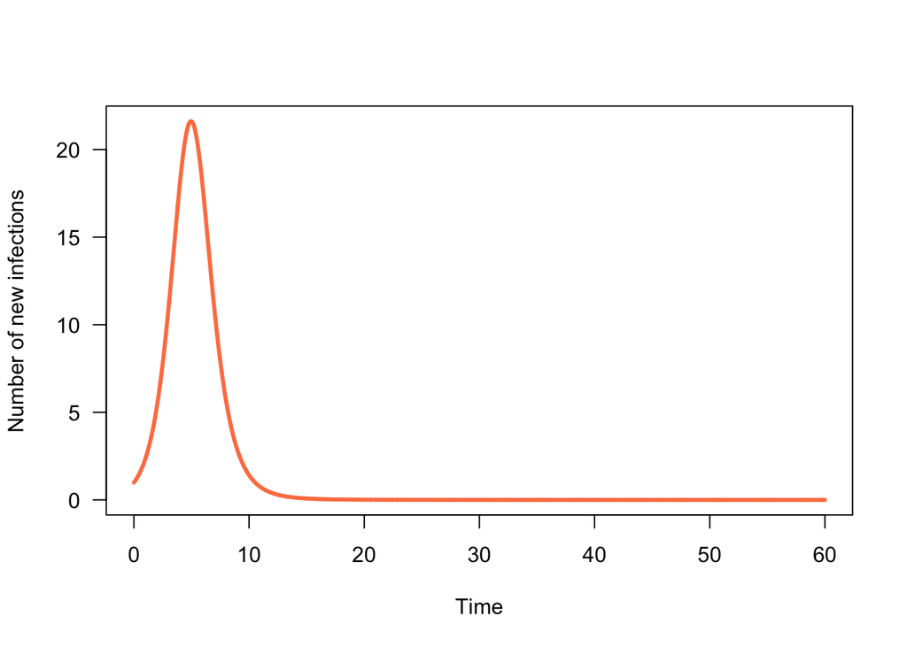

```r
plot(x=tset, y=(beta*S.simu1*I.simu1),
     type='l', las=1, col=Icol, lwd=3,
     xlab= 'Time', ylab='Number of new infections')
```

```r
New_infections <- beta*S.simu1*I.simu1
max_NI <- max(New_infections)
#need to pull max value
for(i in 1:length(tset)){
  if (New_infections[i]==max_NI){
    Time_max_ni <- tset[i]
  }
}

Time_max_ni
```

```
## [1] 4.962248
```

###b. Incorporating vaccination

Let’s now consider how we could prevent the spread of this disease through vaccination.

Let’s set a vaccination rate $p$ of 0.7, meaning 70% of the population has been vaccinated before this disease arrives.

```r
p <- 0.7
```

Now, when we start our simulation, our initial conditions will be different. We’ll still assume that we start with one infected individual ($I_0 = 1$), but now the number of susceptibles is reduced by vaccination.

We’ll first set our initial conditions, then fill in our holding vectors.

```r
# set up vaccinated class
V <- N*p

# set up init conditions for susceptibles
S0 <- N - V - I0 # HINT: Why is this the same as N*(1-p)-I0?

# holding vectors and initial conditions
N.simu2 <- NaN*tset; N.simu2[1] <- N
S.simu2 <- NaN*tset; S.simu2[1] <- S0
I.simu2 <- NaN*tset; I.simu2[1] <- I0
R.simu2 <- NaN*tset; R.simu2[1] <- N - I0 - S0 - V

#
for(i in 2:length(tset)){
  #
    dt <- tset[i]-tset[i-1]

    # set up our previous values as clean object
    S <- S.simu2[i-1]
    I <- I.simu2[i-1]
    R <- R.simu2[i-1]

    # equations
    dS <- (-beta*S*I)*dt
    dI <- (beta*S*I-gamma*I)*dt
    dR <- (gamma*I)*dt
    dN <- dS+dI+dR

    #
    S.simu2[i] <- S + dS
    I.simu2[i] <- I + dI
    R.simu2[i] <- R + dR
    N.simu2[i] <- N + dN
}
```

Check the output of your `for()` loop!

```r
head(S.simu2)
```

```
## [1] 29.00000 28.99913 28.99826 28.99739 28.99652 28.99565
```

```r
tail(N.simu2)
```

```
## [1] 100 100 100 100 100 100
```

Let’s look at how individuals moved between classes. We’ll designate one more color for vaccinated individuals, then plot the output in a timeseries.

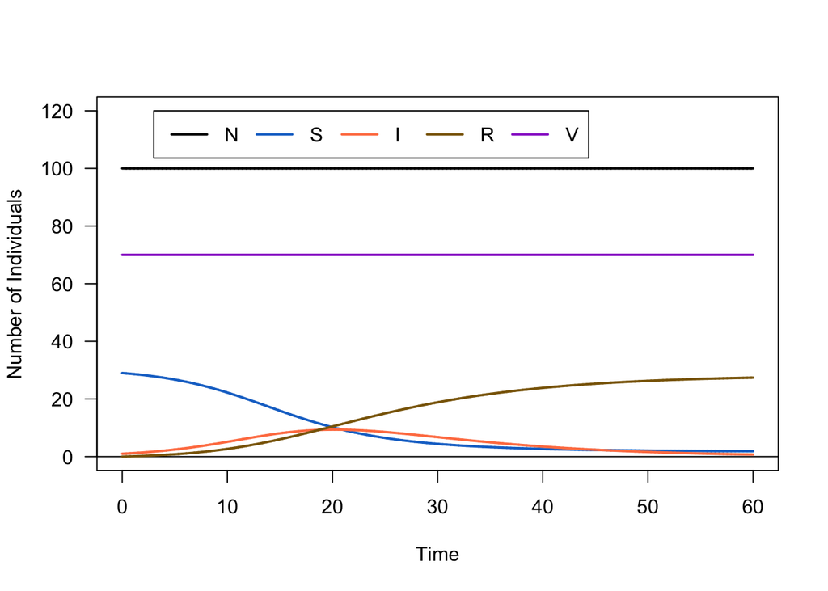

```r
# assign color for vaccinated line
Vcol <- 'darkorchid3'

# plot N.simu2: output of model with vaccination
plot(x = tset, y = N.simu2,
     type = 'l', col = Ncol, las = 1, lwd = 2,
     xlab = 'Time', ylab = 'Number of Individuals',
     ylim = c(0, N*1.2))

# add horizontal line at 0
abline(h = 0)

# plot susceptibles
lines(x = tset, y = S.simu2, col = Scol, lwd = 2)
# plot infected individuals
lines(x = tset, y = I.simu2, col = Icol, lwd = 2)
# plot recovered individuals
lines(x = tset, y = R.simu2, col = Rcol, lwd = 2)
# plot vaccinated individuals
lines(x = tset, y = rep(V,length(tset)), col = Vcol, lwd = 2)

# add a legend
legend(x = max(tset)*0.05, y = N*1.2,
       lwd = 2,
       legend = c('N','S','I','R','V'),
       col = c(Ncol, Scol, Icol, Rcol, Vcol),
       horiz = TRUE)
```

Now, let’s compare the incidence graphs for the two scenarios (unvaccinated vs. 70% vaccinated).

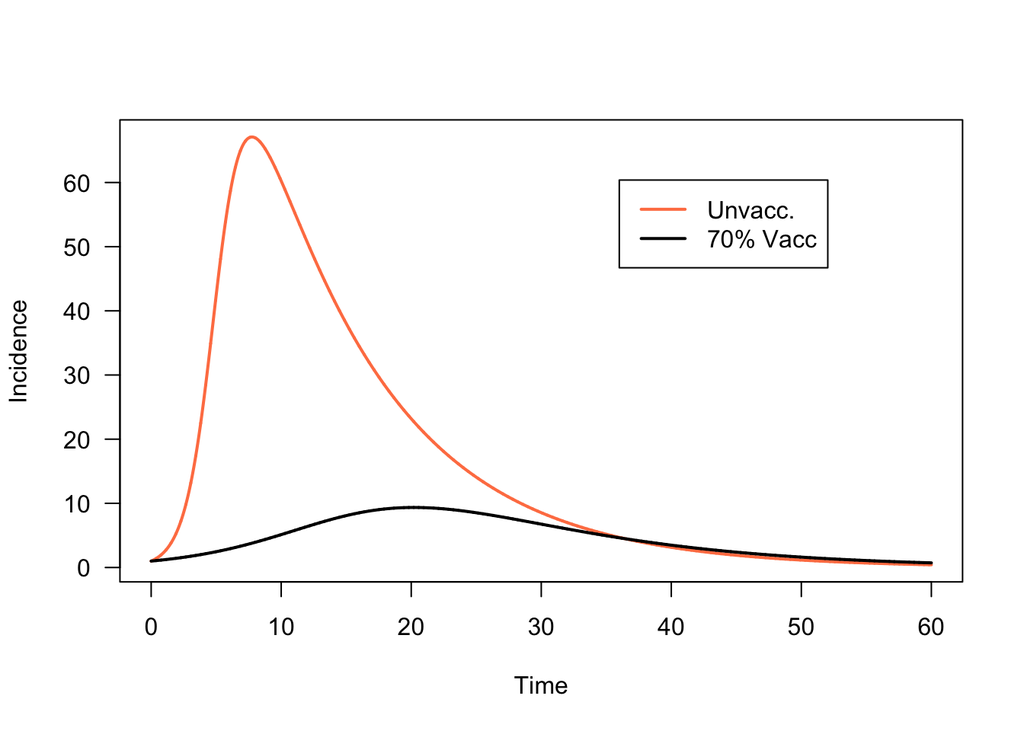

```r
# plot I.simu1 from the unvaccinated population
plot(x = tset, y = I.simu1,
     col = Icol, type = 'l', lwd = 2, las = 1,
     xlab = 'Time', ylab = 'Incidence')

# plot I.simu2 from the 70% vaccinated population
lines(x = tset, y = I.simu2, col = 'black', lwd = 2)

# add a legend
legend(x = max(tset)*0.6, y = max(I.simu1)*.9,
       lwd = 2,
       legend = c('Unvacc.', '70% Vacc'),
       col = c(Icol, 'black'))
```

####Think, Pair, Share 2: 1. How did vaccination change the dynamics that you observed?

Less people got infected and there was less of a spike in infections

2. Did vaccination create herd immunity? In other words, were any unvaccinated individuals protected? **Hint:** First plot the number of susceptible individuals over time, and look at the number of susceptibles at the end of the disease - what do you notice?

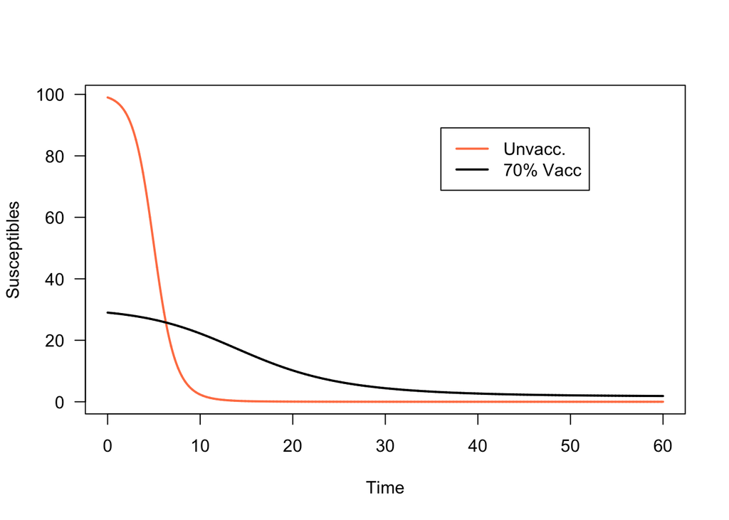

```r
# plot I.simu1 from the unvaccinated population
plot(x = tset, y = S.simu1,
     col = Icol, type = 'l', lwd = 2, las = 1,
     xlab = 'Time', ylab = 'Susceptibles')

# plot I.simu2 from the 70% vaccinated population
lines(x = tset, y = S.simu2, col = 'black', lwd = 2)

# add a legend
legend(x = max(tset)*0.6, y = max(S.simu1)*.9,
       lwd = 2,
       legend = c('Unvacc.', '70% Vacc'),
       col = c(Icol, 'black'))
```

3. Add a line to your incidence graph for a higher rate of vaccination, $p_2$, of 0.8. (Don’t forget to change the legend!) How does this compare?

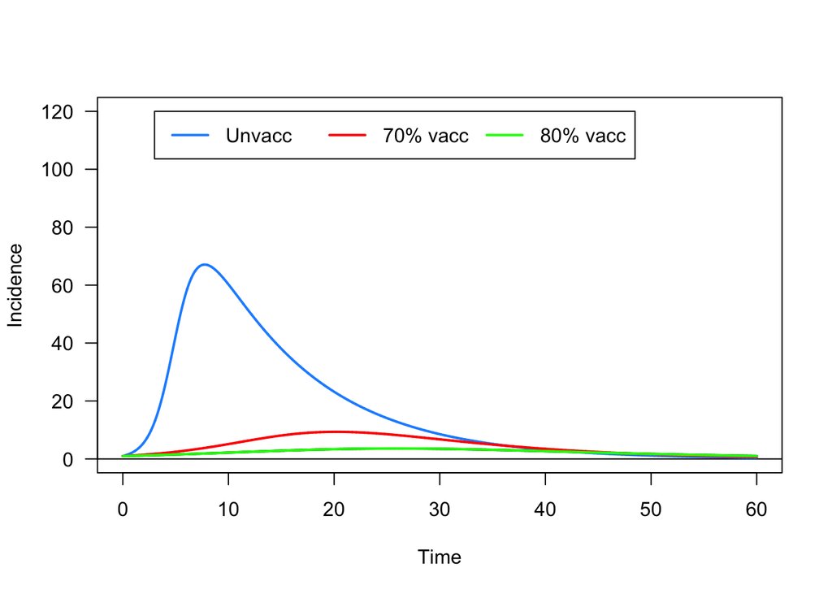

```r
p_2 <- 0.8
# set up vaccinated class
V2 <- N*p_2

# set up init conditions for susceptibles
S0 <- N - V2 - I0 # HINT: Why is this the same as N*(1-p)-I0?

# holding vectors and initial conditions
N.simu3 <- NaN*tset; N.simu3[1] <- N
S.simu3 <- NaN*tset; S.simu3[1] <- S0
I.simu3 <- NaN*tset; I.simu3[1] <- I0
R.simu3 <- NaN*tset; R.simu3[1] <- N - I0 - S0 - V2

#
for(i in 2:length(tset)){
  #
    dt <- tset[i]-tset[i-1]

    # set up our previous values as clean object
    S <- S.simu3[i-1]
    I <- I.simu3[i-1]
    R <- R.simu3[i-1]

    # equations
    dS <- (-beta*S*I)*dt
    dI <- (beta*S*I-gamma*I)*dt
    dR <- (gamma*I)*dt
    dN <- dS+dI+dR

    # outputs
    S.simu3[i] <- S + dS
    I.simu3[i] <- I + dI
    R.simu3[i] <- R + dR
    N.simu3[i] <- N + dN
}

plot(x = tset, y = I.simu3,
     type = 'l', col = Ncol, las = 1, lwd = 2,
     xlab = 'Time', ylab = 'Incidence',
     ylim = c(0, N*1.2))

# add horizontal line at 0
abline(h = 0)

# plot susceptibles
lines(x = tset, y = I.simu1, col = 'dodgerblue', lwd = 2)
# plot infected individuals
lines(x = tset, y = I.simu2, col = 'red', lwd = 2)
# plot recovered individuals
lines(x = tset, y = I.simu3, col = 'green', lwd = 2)

# add a legend
legend(x = max(tset)*0.05, y = N*1.2,
       lwd = 2,
       legend = c('Unvacc','70% vacc', '80% vacc'),
       col = c('dodgerblue', 'red', 'green'),
       horiz = TRUE)
```

Check the output of your `for()` loop!

```r
head(S.simu3)
```

```
## [1] 19.00000 18.99943 18.99886 18.99829 18.99772 18.99715
```

```r
tail(N.simu3)
```

```
## [1] 100 100 100 100 100 100
```

###c. Calculating vaccination rates to prevent an outbreak Let’s say you were a public health official interested in preventing this disease from having the potential to create an epidemic in your population. Your goal is to bring the basic reproduction number $R_0$ below 1.

Recall:

$$\begin{align}
R_0 &= \frac{\beta S}{\gamma} \\
\end{align}$$
What is $R_0$ for this disease when it *first* enters the population?

```r
R0 <- beta * N / gamma

# Why are we using N in place of S in the above formulation? everyone is suceptible so N=S
```

Recall that:
$$\begin{align}
R_V &= R_0 (1-p) \\
\end{align}$$

What level of vaccination (let’s call it `p_crit` for “critical vaccination level”) would prevent this disease from having an epidemic? HINT: Set $R_V = 1$.

```r
p_crit <- 1 - 1/R0
```

Let’s check that prediction by calculating population sizes with this new $p_{crit}$.

```r
# set initial conditions
V3 <- N*p_crit
S0 <- N - V3 - I0

# create holding vectors and fill with initial conditions
N.simu4 <- NaN*tset; N.simu4[1] <- N
S.simu4 <- NaN*tset; S.simu4[1] <- S0
I.simu4 <- NaN*tset; I.simu4[1] <- I0
R.simu4 <- NaN*tset; R.simu4[1] <- N - I0 - S0 - V3

# for each timestep
for(i in 2:length(tset)){
  # calculate change in time
    dt <- tset[i]-tset[i-1]

    # assign S, I, and R
    S <- S.simu4[i-1]
    I <- I.simu4[i-1]
    R <- R.simu4[i-1]

    # calculate change in size of each stage
    dS <- (-beta*S*I)*dt
    dI <- (beta*S*I-gamma*I)*dt
    dR <- (gamma*I)*dt
    dN <- dS+dI+dR

    # calculate total size of each stage and store in holding vector
    S.simu4[i] <- S + dS
    I.simu4[i] <- I + dI
    R.simu4[i] <- R + dR
    N.simu4[i] <- N + dN
}
```

Check the output of your `for()` loop!

Now, let’s plot a timeseries.

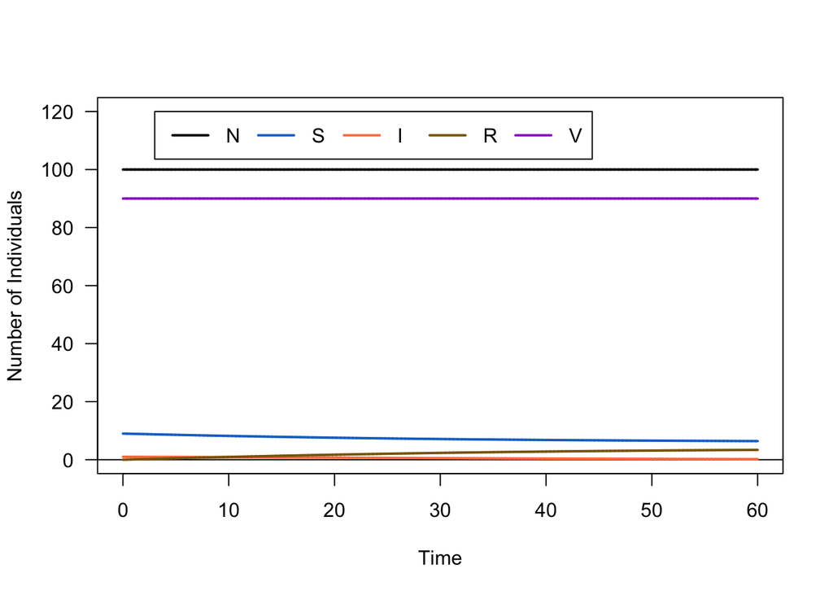

```r
# plot N.simu4
plot(x = tset, y = N.simu4,
     type = 'l', col = Ncol, las = 1, lwd = 2,
     xlab = 'Time', ylab = 'Number of Individuals',
     ylim = c(0,N*1.2))

# add a horizontal line at 0
abline(h = 0)

# plot susceptibles
lines(x = tset, y = S.simu4, col = Scol, lwd = 2)
# plot infected individuals
lines(x = tset, y = I.simu4, col = Icol, lwd = 2)
# plot recovered individuals
lines(x = tset, y = R.simu4, col = Rcol, lwd = 2)
# plot vaccinated individuals
lines(x = tset, y = rep(V3, length(tset)), col = Vcol, lwd = 2)

# add a legend
legend(x = max(tset)*0.05, y = N*1.2,
       lwd = 2,
       legend = c('N', 'S', 'I', 'R', 'V'),
       col = c(Ncol, Scol, Icol, Rcol, Vcol),
       horiz = TRUE)
```

Let’s zoom in on the susceptible, infected, & recovered to see what’s going on a bit better. This is almost the same code as above, but now we’re setting a different `ylim` value.

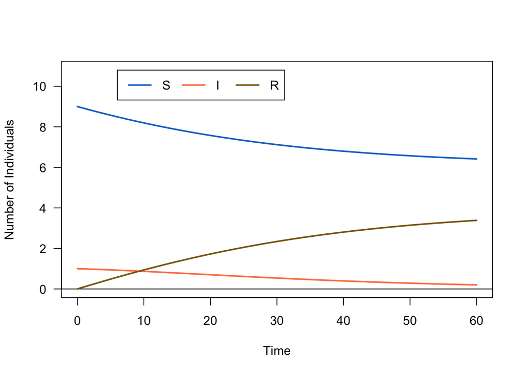

```r
# plot S.simu4
plot(x = tset, y = S.simu4,
     type = 'l', col = Scol, las = 1, lwd = 2,
     xlab = 'Time', ylab = 'Number of Individuals',
     ylim = c(0, max(S.simu4)*1.2))

# add a horizontal line at 0
abline(h = 0)

# plot I.simu4
lines(x = tset, y = I.simu4, col = Icol, lwd = 2)
# plot R.simu4
lines(x = tset, y = R.simu4, col = Rcol, lwd = 2)

# add a legend
legend(x = max(tset)*0.1, y = max(S.simu4)*1.2,
       lwd = 2,
       legend = c('S','I','R'),
       col = c(Scol, Icol, Rcol),
       horiz = TRUE)
```

What we can see is that, while not all susceptible individuals were protected by herd immunity, the number of sick individuals declined monotonically (that is, was always declining at all times) over time. So, we prevented an outbreak!

We can also see this by adding this scenario to our incidence graph:

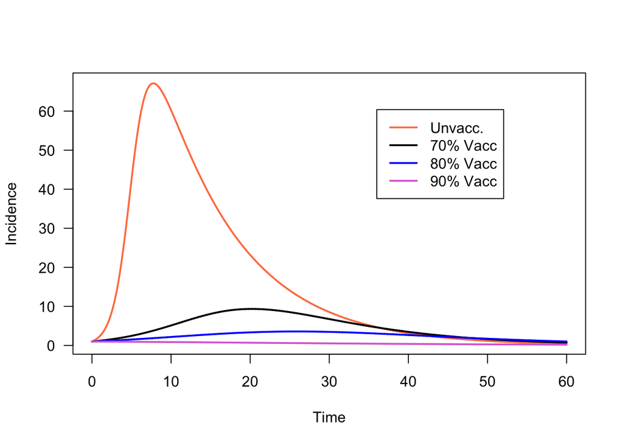

```r
# plot infected individuals from unvaccinated population
plot(x = tset, y = I.simu1,
     col = Icol, type = 'l', lwd = 2, las = 1,
     xlab = 'Time', ylab = 'Incidence')

# plot infected individuals from 70% vaccinated population
lines(x = tset, y = I.simu2, col = 'black', lwd = 2)
# plot infected individuals from 80% vaccinated population
lines(x = tset, y = I.simu3, col = 'blue', lwd = 2)
# plot infected individuals from 90% vaccinated population
lines(x = tset, y = I.simu4, col = 'orchid', lwd = 2)

# add a legend
legend(x = max(tset)*0.6, y = max(I.simu1)*.9,
       lwd = 2,
       legend = c('Unvacc.', '70% Vacc', '80% Vacc', '90% Vacc'),
       col = c(Icol, 'black', 'blue', 'orchid'))
```

###d. Dependence of R_0 and p_crit on disease biology Let’s consider how $R_0$, and the corresponding vaccination rate that we need to prevent an outbreak, depend on one of the parameters, $\beta$.

First, given that:

$$\begin{align}
R_0 &= \frac{\beta N}{\gamma} \\
\end{align}$$

What prediction would you make for $R_0$ as $\beta$ increases? For $p_crit$ as $\beta$ increases? Do these predictions make biological sense?

Let’s compute $\beta$, $R_0$, and $p_{crit}$:

```r
#
beta_set <- seq(from = 0.001, to = 0.1, length.out = 100)

#
R0_set <- beta_set*N/gamma

#
p_crit_set <- 1 - 1/R0_set
```

Now we can visualize. First, $\beta$ as a function of $R_0$:

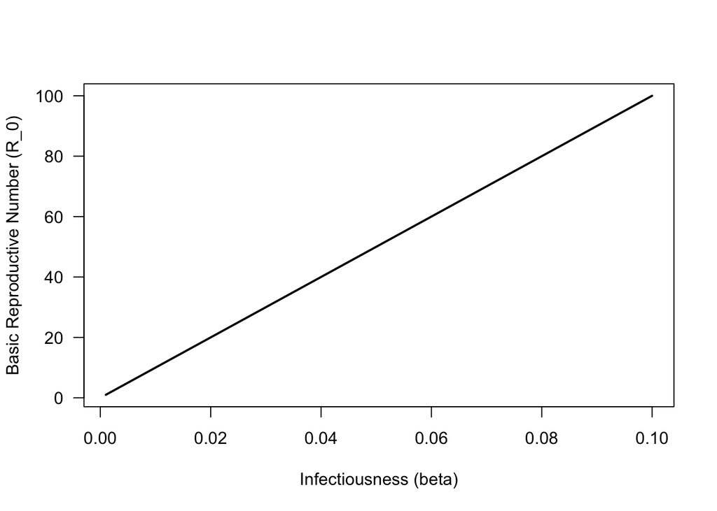

```r
plot(x = beta_set, y = R0_set,
     type = 'l', las = 1, lwd = 2,
     xlab = 'Infectiousness (beta)', ylab = 'Basic Reproductive Number (R_0)')
```

Then, $\beta$ as a function of $p_{crit}$:

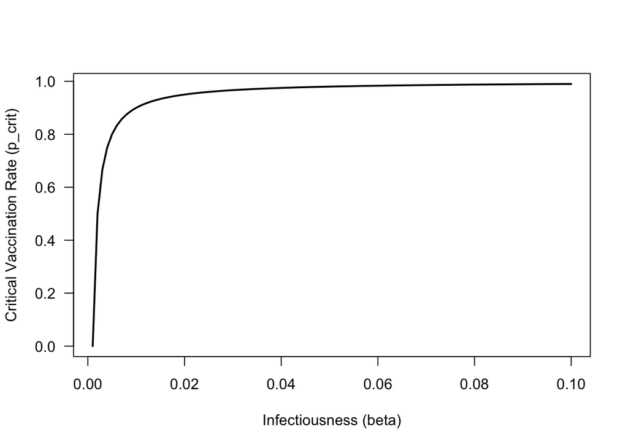

```r
plot(x = beta_set, y = p_crit_set,
     type = 'l', las = 1, lwd = 2,
     xlab = 'Infectiousness (beta)', ylab = 'Critical Vaccination Rate (p_crit)')
```

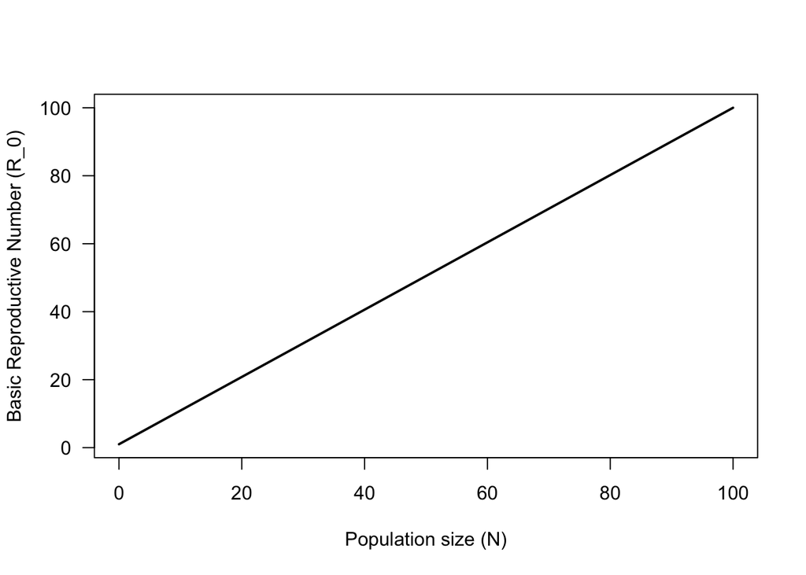

```r
# create a vector of values for N over which to calculate R0
Nset <- seq(from = 0, to = 100, length.out = 100)

# calculate R0 for each value of N
R0_set.N <- beta*Nset/gamma

# plot R0 as a function of N
plot(x = Nset, y = R0_set,
     type = 'l', las = 1, lwd = 2,
     xlab = 'Population size (N)', ylab = 'Basic Reproductive Number (R_0)')
```

##3. Bonus Material

Researchers at University of Georgia have put together a series of Shiny/R Apps for simulating disease. Explore their [collection of models](https://shiny.ovpr.uga.edu/DSAIDE/). You can also download their code.

If you are interested in coding more advanced simulations of disease spread, check out work on [epidemic simulators with transparent coding](https://reactfordataviz.com/articles/corona-simulation/).

# HW 1

1. Make a single Incidence graph (plot number of infected individuals – $I$ – over time) that overlays the following scenarios for a population of $N$ = 100. Be sure to include a legend so that we can differentiate between them!

```r
###########################################################
# 1a. With a black line: beta = 0.01, gamma = 0.1, p = 0 #
###########################################################
# population size
N_hw1 <- 100

beta1a <- 0.01   # infection rate
gamma1a <- 0.1  # recovery rate
p1a <- 0 #vaccination rate

# initial infected individual
I0a <- 1

# starting number of susceptibles
S0_hw1 <- N_hw1 - I0a

# starting number of recovered individuals
R0_hw1 <- 0

# time steps
tset <- seq(from = 0, to = 60, length.out = 20000) # sequence of timesteps from 0 to 60 with a length of 20000

# holding vector for N (population size)
N.hw1a <- NaN*tset # vector of the same length as tset that is filled with NaNs
N.hw1a[1] <- N_hw1 # set the initial population size

# holding vector for I (infected individuals)
I.hw1a <- NaN*tset# vector of the same length as tset that is filled with NaNs
I.hw1a[1] <- I0a # set the initial number of infected individuals

# holding vector for S (susceptible individuals)
S.hw1a <- NaN*tset # vector of the same length as tset that is filled with NaNs
S.hw1a[1] <- S0_hw1 # set the initial number of susceptible individuals


# for each element i from the second to the last
for(i in 2:length(tset)){
  # calculate change in time
    dt <- tset[i]-tset[i-1] # change in time is the difference between the ith timepoint and the previous timepoint

    # assign S, I, and R
    Sa <- S.hw1a[i-1] # susceptible individuals at previous timepoint
    Ia <- I.hw1a[i-1] # infected individuals at previous timepoint

    # calculate change in size of each stage
    dSa <- (-beta1a * Sa * Ia)*dt # change in number of susceptible individuals over the time interval dt
    dIa <- (beta1a*Sa*Ia - gamma1a*Ia)*dt # change in number of infected individuals over the time interval dt

    # calculate total size of each stage and store in holding vector
    S.hw1a[i] <- Sa + dSa # number of susceptible individuals at ith timepoint is equal to the number of susceptible individuals at the previous timepoint (remember we set S <- S.simu1[i-1]) plus the change in susceptible individuals over the time interval dt
    I.hw1a[i] <- Ia + dIa # number of infected individuals at ith timepoint is equal to the number of infected individuals at the previous timepoint plus the change in infected individuals over the time interval dt
}

head(S.hw1a) # use head() to look at the first 6 elements
```

```
## [1] 99.00000 98.99703 98.99405 98.99107 98.98807 98.98507
```

```r
tail(S.hw1a) # use tail() to look at the last 6 elements
```

```
## [1] 0.004664548 0.004664488 0.004664429 0.004664369 0.004664309 0.004664250
```

```r
##########################################################
# 1b. With a blue line: beta = 0.05, gamma = 0.1, p = 0 #
##########################################################
beta1b <- 0.05   # infection rate
gamma1b <- 0.1  # recovery rate
p1b <- 0


# initial infected individual
I0b <- 1

# starting number of susceptibles
S0_hw1 <- N_hw1 - I0b

# starting number of recovered individuals
R0_hw1 <- 0

# time steps
tset <- seq(from = 0, to = 60, length.out = 20000) # sequence of timesteps from 0 to 60 with a length of 20000

# holding vector for N (population size)
N.hw1b <- NaN*tset # vector of the same length as tset that is filled with NaNs
N.hw1b[1] <- N_hw1 # set the initial population size

# holding vector for I (infected individuals)
I.hw1b <- NaN*tset# vector of the same length as tset that is filled with NaNs
I.hw1b[1] <- I0b # set the initial number of infected individuals

# holding vector for S (susceptible individuals)
S.hw1b <- NaN*tset # vector of the same length as tset that is filled with NaNs
S.hw1b[1] <- S0_hw1 # set the initial number of susceptible individuals


# for each element i from the second to the last
for(i in 2:length(tset)){
  # calculate change in time
    dt <- tset[i]-tset[i-1] # change in time is the difference between the ith timepoint and the previous timepoint

    # assign S, I, and R
    Sb <- S.hw1b[i-1] # susceptible individuals at previous timepoint
    Ib <- I.hw1b[i-1] # infected individuals at previous timepoint
#   R <- R.simu1[i-1] # recovered individuals at previous timepoint

    # calculate change in size of each stage
    dSb <- (-beta1b * Sb * Ib)*dt # change in number of susceptible individuals over the time interval dt
    dIb <- (beta1b*Sb*Ib - gamma1b*Ib)*dt # change in number of infected individuals over the time interval dt
#   dR <- (gamma * I)*dt # change in number of recovered individuals over the time interval dt
#   dN <- dS+dI+dR  # change in population size over the time interval dt

    # calculate total size of each stage and store in holding vector
    S.hw1b[i] <- Sb + dSb # number of susceptible individuals at ith timepoint is equal to the number of susceptible individuals at the previous timepoint (remember we set S <- S.simu1[i-1]) plus the change in susceptible individuals over the time interval dt
    I.hw1b[i] <- Ib + dIb # number of infected individuals at ith timepoint is equal to the number of infected individuals at the previous timepoint plus the change in infected individuals over the time interval dt
}

head(S.hw1b) # use head() to look at the first 6 elements
```

```
## [1] 99.00000 98.98515 98.97008 98.95480 98.93930 98.92358
```

```r
tail(S.hw1b) # use tail() to look at the last 6 elements
```

```
## [1] 1.825699e-20 1.825625e-20 1.825550e-20 1.825475e-20 1.825401e-20
## [6] 1.825326e-20
```

```r
###########################################################
# 1c. With a green line: beta = 0.01, gamma = 0.3, p = 0 #
###########################################################

beta1c <- 0.01   # infection rate
gamma1c <- 0.3  # recovery rate
p1c <- 0 #vaccination rate


# initial infected individual
I0c <- 1

# starting number of susceptibles
S0_hw1 <- N_hw1 - I0c

# starting number of recovered individuals
R0_hw1 <- 0

# time steps
tset <- seq(from = 0, to = 60, length.out = 20000) # sequence of timesteps from 0 to 60 with a length of 20000

# holding vector for N (population size)
N.hw1c <- NaN*tset # vector of the same length as tset that is filled with NaNs
N.hw1c[1] <- N_hw1 # set the initial population size

# holding vector for I (infected individuals)
I.hw1c <- NaN*tset# vector of the same length as tset that is filled with NaNs
I.hw1c[1] <- I0c # set the initial number of infected individuals

# holding vector for S (susceptible individuals)
S.hw1c <- NaN*tset # vector of the same length as tset that is filled with NaNs
S.hw1c[1] <- S0_hw1 # set the initial number of susceptible individuals


# for each element i from the second to the last
for(i in 2:length(tset)){
  # calculate change in time
    dt <- tset[i]-tset[i-1] # change in time is the difference between the ith timepoint and the previous timepoint

    # assign S, I, and R
    Sc <- S.hw1c[i-1] # susceptible individuals at previous timepoint
    Ic <- I.hw1c[i-1] # infected individuals at previous timepoint

    # calculate change in size of each stage
    dSc <- (-beta1c * Sc * Ic)*dt # change in number of susceptible individuals over the time interval dt
    dIc <- (beta1c*Sc*Ic - gamma1c*Ic)*dt # change in number of infected individuals over the time interval dt

    # calculate total size of each stage and store in holding vector
    S.hw1c[i] <- Sc + dSc # number of susceptible individuals at ith timepoint is equal to the number of susceptible individuals at the previous timepoint (remember we set S <- S.simu1[i-1]) plus the change in susceptible individuals over the time interval dt
    I.hw1c[i] <- Ic + dIc # number of infected individuals at ith timepoint is equal to the number of infected individuals at the previous timepoint plus the change in infected individuals over the time interval dt
}

head(S.hw1c) # use head() to look at the first 6 elements of
```

```
## [1] 99.00000 98.99703 98.99405 98.99107 98.98808 98.98509
```

```r
tail(S.hw1c) # use tail() to look at the last 6 elements of
```

```
## [1] 4.035982 4.035982 4.035982 4.035982 4.035982 4.035982
```

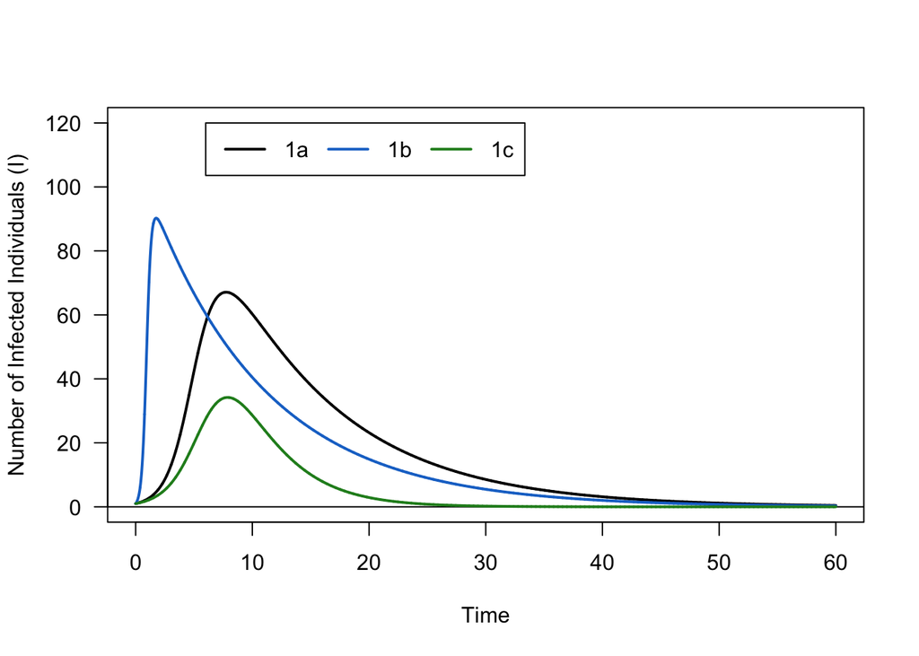

```r
Icola <- 'black' # color to use for a
Icolb <- 'dodgerblue3' # color to use for plotting b
Icolc <- 'forestgreen' # color to use for plotting c


# plot N.hw1a
plot(x = tset, y = N.hw1a, # x-variable = time, y- variable = population size
     type = 'l', # plot data as a line
     col = Ncol, # use the color we assigned for population size
     las = 1, # horizontal y-axis tick marks
     lwd=2, # line thickness
     xlab = 'Time', ylab = 'Number of Infected Individuals (I)', # x and y-axis labels
     ylim = c(0,N*1.2)) # y-axis limits

# add a horizontal line at 0
abline(h = 0)

# add lines showing the number of susceptibles, infected, and recovered individuals
# plot infected individuals
lines(x = tset, y = I.hw1a, col = Icola, lwd = 2)# x = time, y = infected individuals, use the color we assigned for infected individuals, and specify line thickness with lwd
lines(x = tset, y = I.hw1b, col = Icolb, lwd = 2)# x = time, y = infected individuals, use the color we assigned for infected individuals, and specify line thickness with lwd
lines(x = tset, y = I.hw1c, col = Icolc, lwd = 2)# x = time, y = infected individuals, use the color we assigned for infected individuals, and specify line thickness with lwd

# add a legend
legend(x = max(tset)*0.1, y = N*1.2, # x and y locations of the legend
       lwd = 2, # thickness of the lines in the legend
       legend = c('1a', '1b', '1c'), # labels for the legend elements
       col = c(Icola, Icolb, Icolc), # colors for the legend elements
       horiz = TRUE) # arrange the legend elements in a row
```

/1 point black line  
/1 point blue line  
/1 point green line  
/1 point legend  
/1 point axes labels  
= /5 points total

# HW 2

2. Describe the differences between the scenarios you plotted above.

## 2a. What is the effect of decreasing infectiousness?

**Decreasing infectiousness (beta) leads to less individuals getting infected and the peak of infection rates occurring later.**

## 2b. What is the effect of increasing recovery rates?

**Increasing recovery rate leads to a decrease in the number of individuals that gets infected, but the peak of infection occurs at the same time.**

/2 points for the effect of decreasing infectiousness  
/2 points for the effect of increasing infectiousness  
= /4 points total

# HW 3

3. Calculate R_0 for each of each of the disease scenarios in Question 1, assuming an initial susceptible population size $S = 100$. What vaccination proportion ($p$) for each would be required to prevent a disease outbreak?

```r
R01a <- beta1a * N_hw1 / gamma1a # basic reproduction number of the disease
p_crit1a <- 1 - 1/R01a # critical vaccination level that would prevent an epidemic: if R_V = 1, then 1 = R0(1-p), so 1/R0 = 1-p, so p = 1 - 1/R0
p_crit1a
```

```
## [1] 0.9
```

```r
#0.9

R01b <- beta1b * N_hw1 / gamma1b# basic reproduction number of the disease
p_crit1b <- 1 - 1/R01b # critical vaccination level that would prevent an epidemic: if R_V = 1, then 1 = R0(1-p), so 1/R0 = 1-p, so p = 1 - 1/R0
p_crit1b
```

```
## [1] 0.98
```

```r
#0.98

R01c <- beta1c * N_hw1 / gamma1c# basic reproduction number of the disease
p_crit1c <- 1 - 1/R01c # critical vaccination level that would prevent an epidemic: if R_V = 1, then 1 = R0(1-p), so 1/R0 = 1-p, so p = 1 - 1/R0
p_crit1c
```

```
## [1] 0.7
```

```r
#0.7
```

**The vaccination proportion (p_crit) for the “black line” scenario 1 is: ____0.9___**

**The vaccination proportion (p_crit) for the “blue line” scenario 2 is: ____0.98___**

**The vaccination proportion (p_crit) for the “green line” scenario 3 is: ____0.7___**

/2 points for work + answer for $p_{crit}$ scenario 1  
/2 points for work + answer for $p_{crit}$ scenario 2  
/2 points for work + answer for $p_{crit}$ scenario 3  
/1 points for properly setting up the equations and such = /7 points total

# HW 4

4. Run three simulations to check your answers for Part 3. For each, make an incidence diagram (total of 3 incidence diagrams) comparing the unvaccinated scenario (using a black line) with the vaccinated scenario (using a blue line). Don’t forget to (1) label your plots so that we know which corresponds to which scenario, and (2) include a legend indicating which line corresponds to vaccinated vs. unvaccinated.

```r
############################################################
# Unvaccinated black line: beta = 0.01, gamma = 0.1, p = 0 #
# Vaccinated blue line: beta = 0.01, gamma = 0.1, p = 0.9  #
############################################################
# set initial conditions
V1a <- N_hw1*p_crit1a   # set the number of vaccinated individuals equal to the critical number that would prevent an epidemic in this population
S01a <- N_hw1 - V1a - I0a  # initial number of susceptible individuals = all individuals that are not vaccinated or initially infected

# create holding vectors and fill with initial conditions
N.4a <- NaN*tset; N.4a[1] <- N # holding vector for total population size at each timepoint, set initial value to the total population size N
S.4a <- NaN*tset; S.4a[1] <- S01a # holding vector for number of susceptible individuals at each timepoint, set initial value to S0
I.4a <- NaN*tset; I.4a[1] <- I0a # holding vector for number of infected individuals at each timepoint, set initial value to I0
#R.simu4 <- NaN*tset; R.simu4[1] <- N - I0 - S0 - V3 # holding vector for number of recovered individuals at each timepoint, set initial value to the initial number of individuals that are not infected, susceptible, or vaccinated

# for each element i from the second to the last
for(i in 2:length(tset)){
  # calculate change in time
    dt <- tset[i]-tset[i-1] # change in time is the difference between the ith timepoint and the previous timepoint

    # assign S, I, and R
    S4a <- S.4a[i-1] # susceptible individuals at previous timepoint
    I4a <- I.4a[i-1] # infected individuals at previous timepoint
#   R <- R.simu4[i-1] # recovered individuals at previous timepoint

    # calculate change in size of each stage
    dS4a <- (-beta1a * Sa * Ia)*dt # change in number of susceptible individuals over the time interval dt
    dI4a <- (beta1a*Sa*Ia - gamma1a*Ia)*dt # change in number of infected individuals over the time interval dt
    dR4a <- (gamma1a * Ia)*dt # change in number of recovered individuals over the time interval dt
#   dN <- dS+dI+dR  # change in population size over the time interval dt

    # calculate total size of each stage and store in holding vector
    I.4a[i] <- Ia + dI4a # number of infected individuals at ith timepoint is equal to the number of infected
}

head(I.4a)
```

```
## [1] 1.0000000 0.4260772 0.4260772 0.4260772 0.4260772 0.4260772
```

```r
tail(I.4a)
```

```
## [1] 0.4260772 0.4260772 0.4260772 0.4260772 0.4260772 0.4260772
```

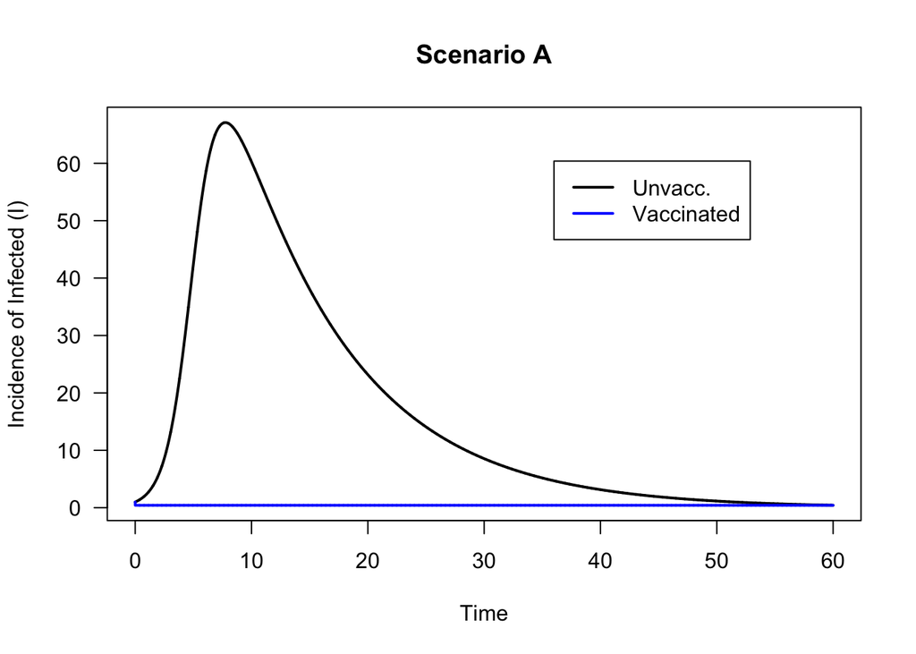

```r
# plot infected individuals from unvaccinated population
plot(x = tset, y = I.hw1a, # x = time, y = number of infected individuals from simulation with no vaccination
     col = 'black', type = 'l', lwd = 2, las = 1, # plot aesthetics
     xlab = 'Time', ylab = 'Incidence of Infected (I)',
     main= 'Scenario A') # axis labels

# plot infected individuals from vaccinated population
lines(x = tset, y = I.4a, col = 'blue', lwd = 2)


# add a legend
legend(x = max(tset)*0.6, y = max(I.hw1a)*.9, # legend location
       lwd = 2, # line thickness
       legend = c('Unvacc.', 'Vaccinated'), # labels of legend elements
       col = c('black', 'blue')) # colors of the legend elements
```

```r
############################################################
# Unvaccinated black line: beta = 0.05, gamma = 0.1, p = 0 #
# Vaccinated blue line: beta = 0.05, gamma = 0.1, p = 0.98 #
############################################################
# set initial conditions
V1b <- N_hw1*p_crit1b   # set the number of vaccinated individuals equal to the critical number that would prevent an epidemic in this population
S01b <- N_hw1 - V1b - I0b  # initial number of susceptible individuals = all individuals that are not vaccinated or initially infected

# create holding vectors and fill with initial conditions
N.4b <- NaN*tset; N.4b[1] <- N # holding vector for total population size at each timepoint, set initial value to the total population size N
S.4b <- NaN*tset; S.4b[1] <- S01b # holding vector for number of susceptible individuals at each timepoint, set initial value to S0
I.4b <- NaN*tset; I.4b[1] <- I0b # holding vector for number of infected individuals at each timepoint, set initial value to I0

# for each element i from the second to the last
for(i in 2:length(tset)){
  # calculate change in time
    dt <- tset[i]-tset[i-1] # change in time is the difference between the ith timepoint and the previous timepoint

    # assign S, I, and R
    S4b <- S.4b[i-1] # susceptible individuals at previous timepoint
    I4b <- I.4b[i-1] # infected individuals at previous timepoint

    # calculate change in size of each stage
    dS4b <- (-beta1b * Sb * Ib)*dt # change in number of susceptible individuals over the time interval dt
    dI4b <- (beta1b*Sb*Ib - gamma1b*Ib)*dt # change in number of infected individuals over the time interval dt
    dR4b <- (gamma1b * Ib)*dt # change in number of recovered individuals over the time interval dt
#   dN <- dS+dI+dR  # change in population size over the time interval dt

    # calculate total size of each stage and store in holding vector
    I.4b[i] <- Ib + dI4b # number of infected individuals at ith timepoint is equal to the number of infected
}

head(I.4b)
```

```
## [1] 1.0000000 0.2723951 0.2723951 0.2723951 0.2723951 0.2723951
```

```r
tail(I.4b)
```

```
## [1] 0.2723951 0.2723951 0.2723951 0.2723951 0.2723951 0.2723951
```

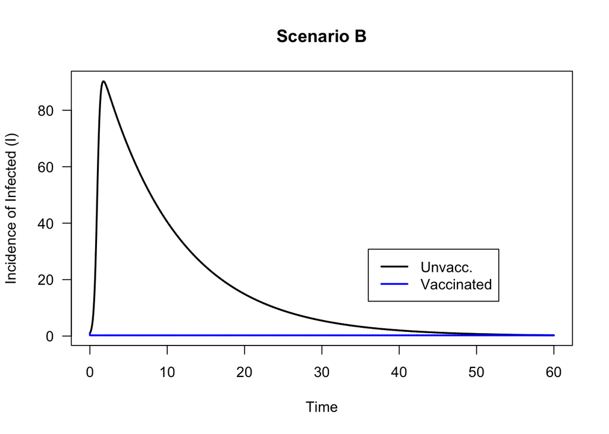

```r
# plot infected individuals from unvaccinated population
plot(x = tset, y = I.hw1b, # x = time, y = number of infected individuals from simulation with no vaccination
     col = 'black', type = 'l', lwd = 2, las = 1, # plot aesthetics
     xlab = 'Time', ylab = 'Incidence of Infected (I)',
     main= 'Scenario B') # axis labels

# plot infected individuals from vaccinated population
lines(x = tset, y = I.4b, col = 'blue', lwd = 2)


# add a legend
legend(x = max(tset)*0.6, y = max(I.hw1c)*.9, # legend location
       lwd = 2, # line thickness
       legend = c('Unvacc.', 'Vaccinated'), # labels of legend elements
       col = c('black', 'blue')) # colors of the legend elements
```

```r
#############################################################
# Unvaccinated black line: beta = 0.01, gamma = 0.3, p = 0  #
# Vaccinated green line: beta = 0.01, gamma = 0.3, p = 0.70 #
#############################################################
# set initial conditions
V1c <- N_hw1*p_crit1c   # set the number of vaccinated individuals equal to the critical number that would prevent an epidemic in this population
S01c <- N_hw1 - V1c - I0c  # initial number of susceptible individuals = all individuals that are not vaccinated or initially infected

# create holding vectors and fill with initial conditions
N.4c <- NaN*tset; N.4c[1] <- N # holding vector for total population size at each timepoint, set initial value to the total population size N
S.4c <- NaN*tset; S.4c[1] <- S01c # holding vector for number of susceptible individuals at each timepoint, set initial value to S0
I.4c <- NaN*tset; I.4c[1] <- I0c # holding vector for number of infected individuals at each timepoint, set initial value to I0

# for each element i from the second to the last
for(i in 2:length(tset)){
  # calculate change in time
    dt <- tset[i]-tset[i-1] # change in time is the difference between the ith timepoint and the previous timepoint

    # assign S, I, and R
    S4c <- S.4c[i-1] # susceptible individuals at previous timepoint
    I4c <- I.4c[i-1] # infected individuals at previous timepoint

    # calculate change in size of each stage
    dS4c <- (-beta1c * Sc * Ic)*dt # change in number of susceptible individuals over the time interval dt
    dI4c <- (beta1c*Sc*Ic - gamma1c*Ic)*dt # change in number of infected individuals over the time interval dt
    dR4c <- (gamma1c * Ic)*dt # change in number of recovered individuals over the time interval dt
#   dN <- dS+dI+dR  # change in population size over the time interval dt

    # calculate total size of each stage and store in holding vector
    I.4c[i] <- Ic + dI4c # number of infected individuals at ith timepoint is equal to the number of infected
}

head(I.4c)
```

```
## [1] 1.000000e+00 9.096032e-05 9.096032e-05 9.096032e-05 9.096032e-05
## [6] 9.096032e-05
```

```r
tail(I.4c)
```

```
## [1] 9.096032e-05 9.096032e-05 9.096032e-05 9.096032e-05 9.096032e-05
## [6] 9.096032e-05
```

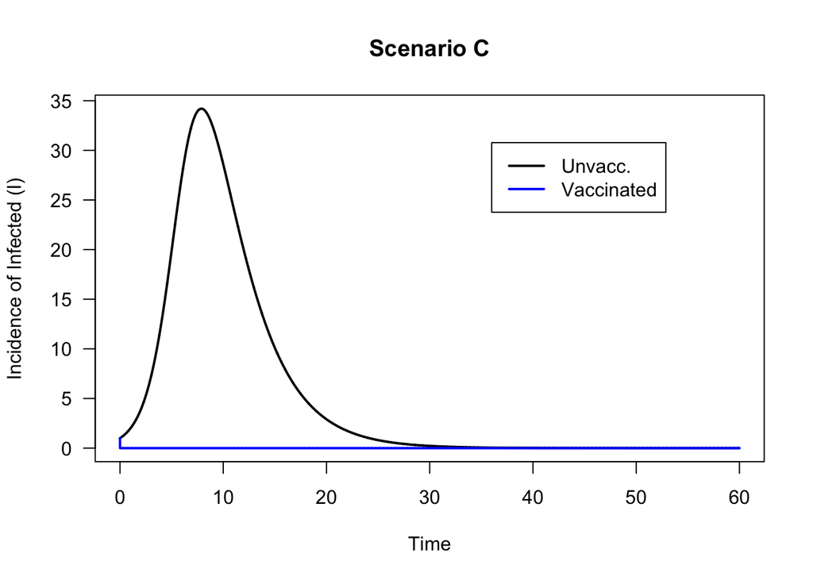

```r
# plot infected individuals from unvaccinated population
plot(x = tset, y = I.hw1c, # x = time, y = number of infected individuals from simulation with no vaccination
     col = 'black', type = 'l', lwd = 2, las = 1, # plot aesthetics
     xlab = 'Time', ylab = 'Incidence of Infected (I)',
     main= 'Scenario C') # axis labels

# plot infected individuals from vaccinated population
lines(x = tset, y = I.4c, col = 'blue', lwd = 2)


# add a legend
legend(x = max(tset)*0.6, y = max(I.hw1c)*.9, # legend location
       lwd = 2, # line thickness
       legend = c('Unvacc.', 'Vaccinated'), # labels of legend elements
       col = c('black', 'blue')) # colors of the legend elements
```

/3 points for unvaccinated lines  
/3 points for vaccinated lines  
/3 points for legend  
/3 points for axes  
= /12 points total (3 plots)

# HW 5

5. Explain how R_0 and p depend upon:
- 5a. infectiousness,
- 5b. recovery time, and
- 5c. population size (assuming N = S, when the disease has not yet arrived).

For each of these (for a total of 6 plots – don’t forget to label the axes of each one!):  
- create a plot of $R_0$ (y-axis) vs. the parameter/variable of interest (x-axis),  
- create a plot of $p$ (y-axis) vs. the parameter of interest (x-axis), and  
- explain the shapes of the graphs based on the biology of disease spread. Do you notice anything odd about the answer to 5c?

Remember that:
$$\begin{align}
R_0 &= \frac{\beta * N}{\gamma} \\
\newline
p_{crit} &= 1 - \frac{1}{R_0}
\end{align}$$

## 5a: Infectiousness

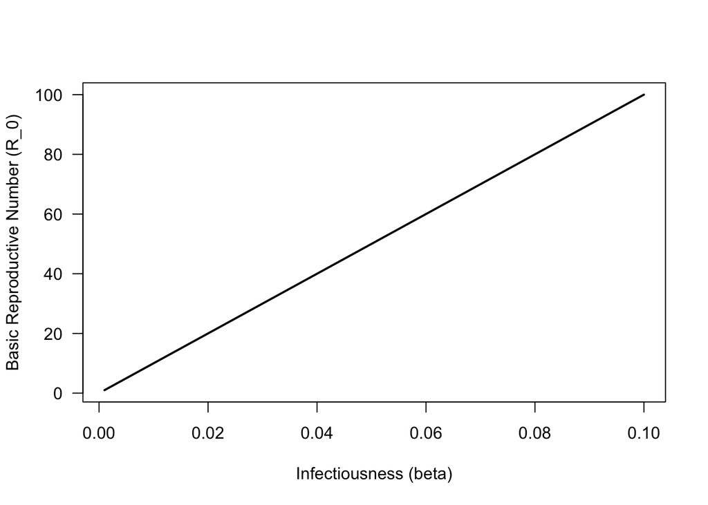

```r
# create a vector of values of beta over which to calculate R0
beta_set <- seq(from = 0.001, to = 0.1, length.out = 100) # sequence from 0.001 to 0.1 with a total length of 100

# calculate R0 for each value of beta
R0_set <- beta_set*N/gamma # R0 = beta*N/gamma

# calculate p_crit for each value of R0
p_crit_set <- 1 - 1/R0_set  # p_crit = 1 - 1/R0

# plot of $R_0$ (y-axis) vs. Infectiousness (x-axis)
plot(x = beta_set, y = R0_set, # x = infectiousness, y = basic reproductive number for each value of infectiousness
     type = 'l', las = 1, lwd = 2, # plot aesthetics
     xlab = 'Infectiousness (beta)', ylab = 'Basic Reproductive Number (R_0)') # axis labels
```

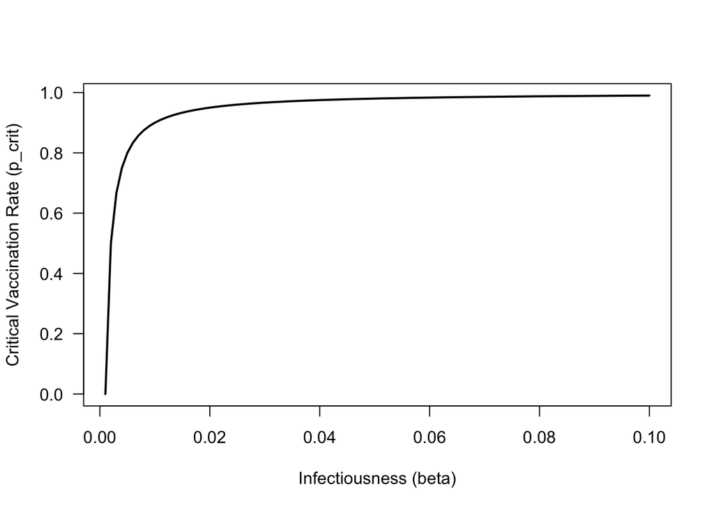

```r
# plot of $p$ (y-axis) vs. Infectiousness (x-axis)
plot(x = beta_set, y = p_crit_set, # x = infectiousness, y = critical vaccination rate needed to prevent an epidemic for each value of infectiousness
     type = 'l', las = 1, lwd = 2, # plot aesthetics
     xlab = 'Infectiousness (beta)', ylab = 'Critical Vaccination Rate (p_crit)') # plot labels
```

explain the shapes of the graphs based on the biology of disease spread

**As infectiousness increases, R_0 increases linearly and p_crit increases asymptotically. USing intuition this makes sense because as infectiousness increases, more people can become infected which leads to. ahigher R_0. Similarly, higher infectiousness causes a need for a higher p_crit, but once it reaches a certain point p_crit is as close to 100% as possible**

## 5b: Recovery time

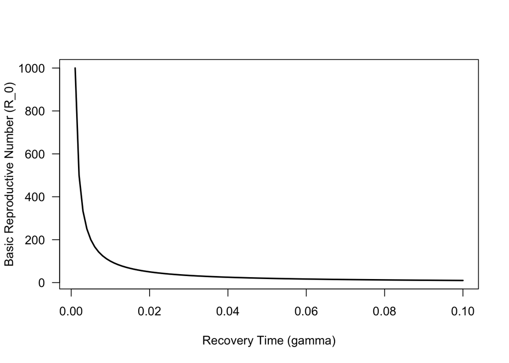

```r
# create a vector of values of beta over which to calculate R0
gamma_set <- seq(from = 0.001, to = 0.1, length.out = 100) # sequence from 0.001 to 0.1 with a total length of 100

# calculate R0 for each value of beta
R0_set.gamma <- beta*N/gamma_set # R0 = beta*N/gamma

# calculate p_crit for each value of R0
p_crit_set.gamma <- 1 - 1/R0_set.gamma  # p_crit = 1 - 1/R0


# plot of $R_0$ (y-axis) vs. Recovery time (x-axis)
plot(x = gamma_set, y = R0_set.gamma, # x = recovery, y = basic reproductive number for each value of recovery time
     type = 'l', las = 1, lwd = 2, # plot aesthetics
     xlab = 'Recovery Time (gamma)', ylab = 'Basic Reproductive Number (R_0)') # axis labels
```

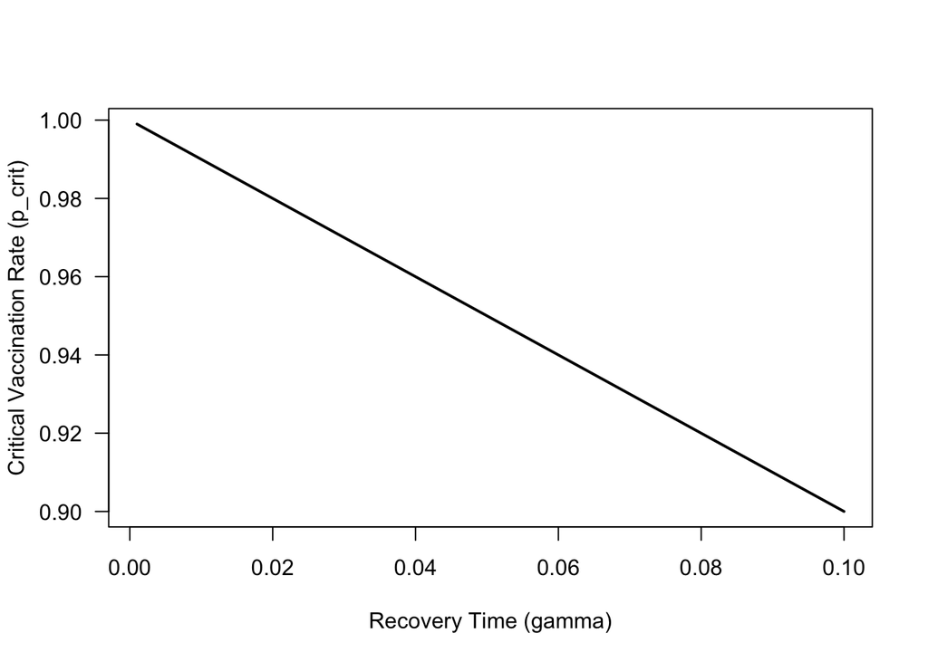

```r
# plot of $p$ (y-axis) vs. Recovery time (x-axis)
plot(x = gamma_set, y = p_crit_set.gamma, # x = recovery, y = critical vaccination rate needed to prevent an epidemic for each value of infectiousness
     type = 'l', las = 1, lwd = 2, # plot aesthetics
     xlab = 'Recovery Time (gamma)', ylab = 'Critical Vaccination Rate (p_crit)') # plot labels
```

explain the shapes of the graphs based on the biology of disease spread

**As recovery time increases, R_0 decreases asymptotically and p_crit decreases linearly. This makes sense because R0 is proportional to the infectious period. A longer recovery time means infected individuals remain infectious for a longer duration, but the effect on R0 diminishes as transmission levels out. In contrast, p_crit decreases linearly because it is directly related to R0 through the equation p_crit = 1−1/R0.**

## 5c: population size

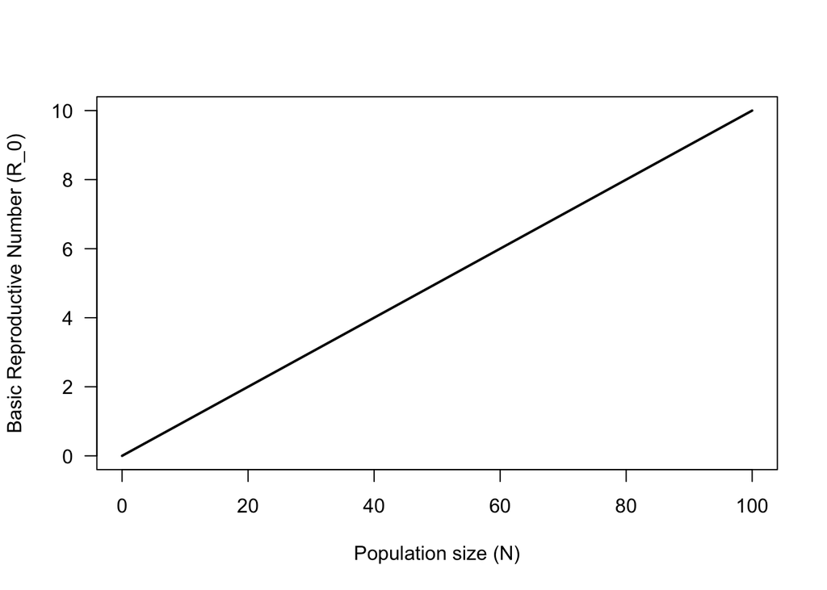

```r
# work here

# plot of $R_0$ (y-axis) vs. population size (x-axis)
# create a vector of values for N over which to calculate R0
Nset.N <- seq(from = 0, to = 100, length.out = 100) # sequence from 1 to 100 with a total length of 100

# calculate R0 for each value of N
R0_set.N <- beta*Nset.N/gamma # R0 = beta*N/gamma

# calculate p_crit for each value of R0
p_crit_set.N <- 1 - 1/R0_set.N  # p_crit = 1 - 1/R0

# plot R0 as a function of N
plot(x = Nset.N, y = R0_set.N, # x = total population size, y = basic reproductive number for each population size
     type = 'l', las = 1, lwd = 2, # plot aesthetics
     xlab = 'Population size (N)', ylab = 'Basic Reproductive Number (R_0)') # axis labels
```

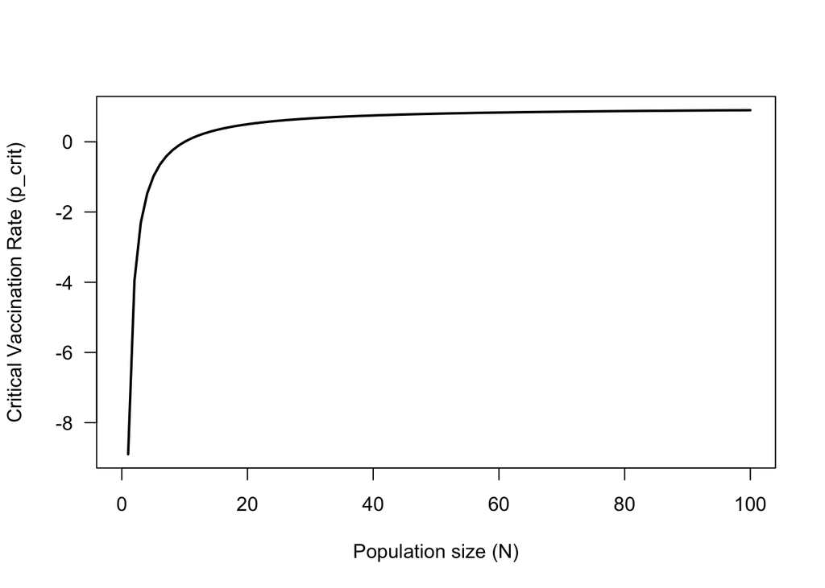

```r
# plot of $p$ (y-axis) vs. population size (x-axis)
plot(x = Nset.N, y = p_crit_set.N, # x = infectiousness, y = p crit
     type = 'l', las = 1, lwd = 2, # plot aesthetics
     xlab = 'Population size (N)', ylab = 'Critical Vaccination Rate (p_crit)') # plot labels
```

explain the shapes of the graphs based on the biology of disease spread

**These graphs show that R_0 increases linearly with N and p_crit increases asmyptotically with N. What I find odd about the shape of these graphs is that R_0 and p_crit should remain constant with population size because the equations rely on proportion of sick individuals, not the number of cases.**

/6 points for explanation of how R_0 and p depend upon infectiousness, recovery time, and population size.  
/6 point per simulation line  
/6 point per set of axes  
/2 point for explanation of negative p_crit values in answer to 5c  
= /20 points total (6 plots)

total = 48 points